# Patient Volume Analysis

## Preface

Following vairables in file `encounters.csv` are relevant to average patient volume calculation:

- `PAT_ENC_CSN_ID`: unique patient id
- `ADT_ARRIVAL_DTTM`: the timestamp that a patient came into the ED
- `ACUITY_LEVEL_C`: the acuities levels of a patient
- `BEHAVIORAL_DAHSB`: whether the patient is a behavioral patient or not

Besides, we will create several new vairables for use:

- `ADT_YEAR`, `ADT_MONTH`, `ADT_WEEKDAYS`, and `ADT_HOUR`

## Data Inspection

### Inspect the distribution of acuity

```
     1      2      3      4      5   null
 11417  56315 130956 165372  31889   1372
```

As we can see, there are only 1372 observations with missing acuity level, which is a small percent and is relatively negligible. We decided to focus on the majority, and filter out those observations with missing acuity level in the data exploration process.

|  | ADT_YEAR | ADT_MONTH | ADT_WEEKDAYS | avg |
| --- | --- | --- | --- | --- |
| 1 | 2014 | January | Monday | 253.75 |
| 2 | 2014 | January | Tuesday | 240 |
| 3 | 2014 | January | Wednesday | 229.5 |
| 4 | 2014 | January | Thursday | 244 |
| 5 | 2014 | January | Friday | 222.6 |
| 6 | 2014 | January | Saturday | 223.2 |
| 7 | 2014 | January | Sunday | 234.5 |
| 8 | 2014 | February | Monday | 245 |
| 9 | 2014 | February | Tuesday | 230 |
| 10 | 2014 | February | Wednesday | 220.25 |

[output cut: 354 more lines]

## Overall Distribution of Patient Volume

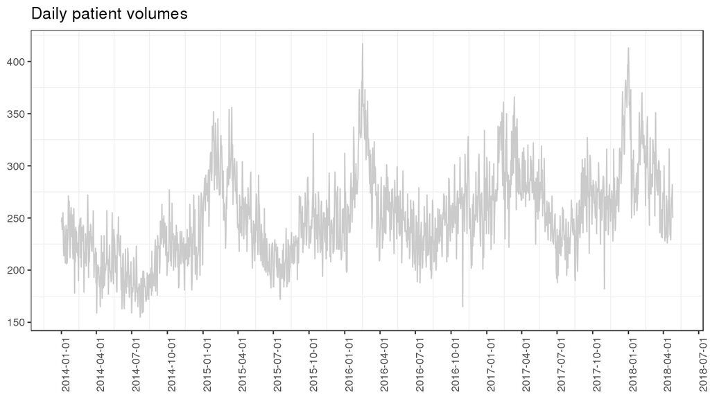

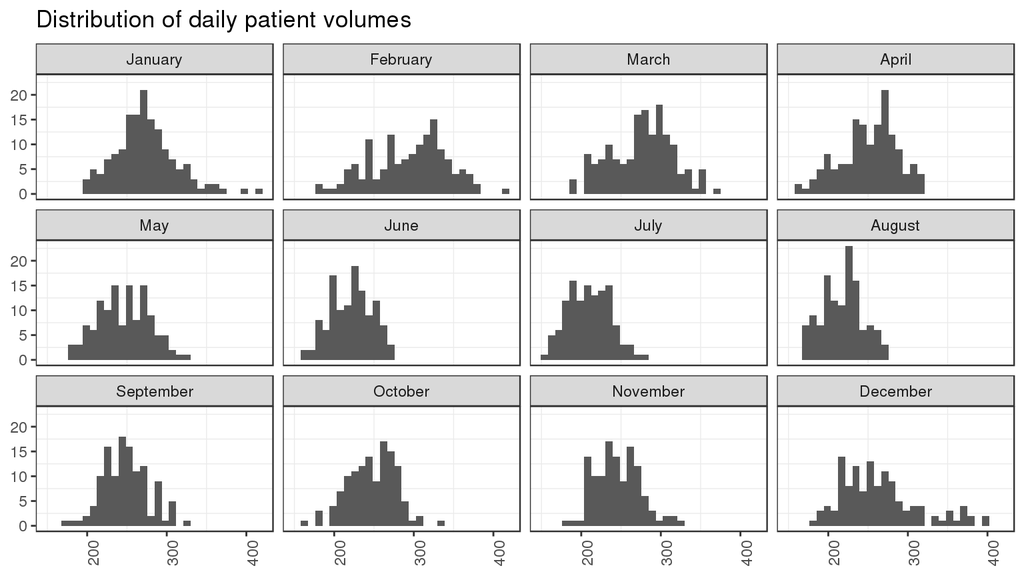

- Demand trend:
  - **Down**: Feburary
  - **Up**: July/August
  - **Slightly Down**: November
  - **Surge**: December
- We see more variation in daily patient volumes in **January, Feburary and December**.
- **June, July and August** have relatively low daily patient volume.
- Peak appeared in January and Feburary.

## Average Patient Volume by Weekday

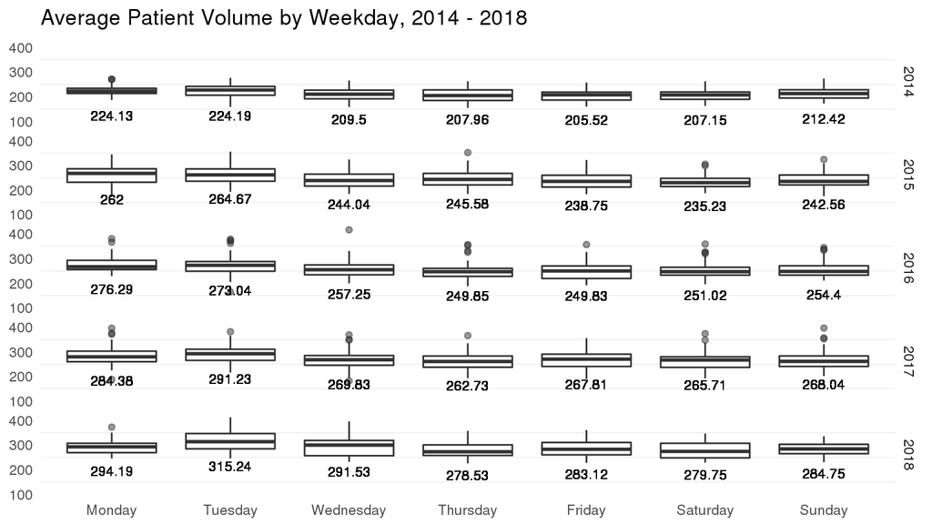

### Mean Comparison Analysis

```
Pairwise mean comparisons (t-test)
Data      : meanComparison
Variables : ADT_WEEKDAYS, avg
Samples   : independent
Confidence: 0.95
Adjustment: Bonferroni

 ADT_WEEKDAYS    mean  n     sd    se     ci
       Monday 264.467 52 36.437 5.053 10.144
      Tuesday 267.395 52 39.389 5.462 10.966
    Wednesday 249.165 52 37.059 5.139 10.317
     Thursday 244.741 52 35.986 4.990 10.018
       Friday 243.975 52 36.640 5.081 10.201
     Saturday 242.720 52 34.344 4.763  9.561
       Sunday 247.382 52 33.497 4.645  9.325

 Null hyp.              Alt. hyp.                         diff   p.value
 Monday = Tuesday       Monday not equal to Tuesday       -2.928 1
 Monday = Wednesday     Monday not equal to Wednesday     15.302 0.759
 Monday = Thursday      Monday not equal to Thursday      19.726 0.137
 Monday = Friday        Monday not equal to Friday        20.492 0.108
 Monday = Saturday      Monday not equal to Saturday      21.748 0.048
 Monday = Sunday        Monday not equal to Sunday        17.085 0.303
 Tuesday = Wednesday    Tuesday not equal to Wednesday    18.230 0.353
 Tuesday = Thursday     Tuesday not equal to Thursday     22.654 0.059
 Tuesday = Friday       Tuesday not equal to Friday       23.420 0.047
 Tuesday = Saturday     Tuesday not equal to Saturday     24.676 0.02
 Tuesday = Sunday       Tuesday not equal to Sunday       20.013 0.132
 Wednesday = Thursday   Wednesday not equal to Thursday    4.424 1
 Wednesday = Friday     Wednesday not equal to Friday      5.190 1
 Wednesday = Saturday   Wednesday not equal to Saturday    6.446 1
 Wednesday = Sunday     Wednesday not equal to Sunday      1.783 1
 Thursday = Friday      Thursday not equal to Friday       0.766 1
 Thursday = Saturday    Thursday not equal to Saturday     2.022 1
 Thursday = Sunday      Thursday not equal to Sunday      -2.641 1
 Friday = Saturday      Friday not equal to Saturday       1.255 1
 Friday = Sunday        Friday not equal to Sunday        -3.407 1
 Saturday = Sunday      Saturday not equal to Sunday      -4.663 1

Signif. codes:  0 '***' 0.001 '**' 0.01 '*' 0.05 '.' 0.1 ' ' 1
```

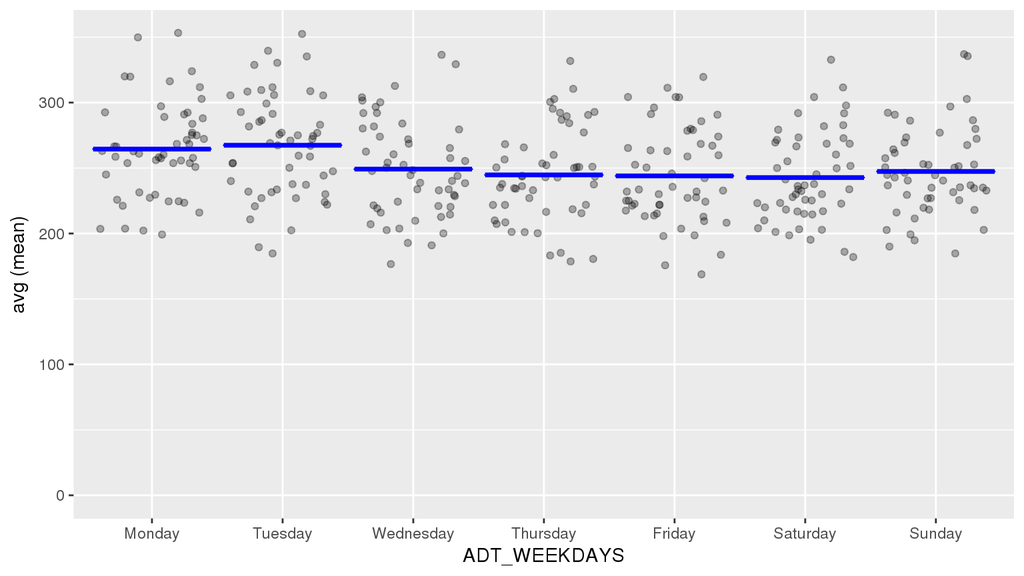

Clearly, the average daily patient volumes across the whole week varied. But from the patient volume history that we have, we can only conclude that the patient volume on Tuesday is normally different from that of Friday and Saturday (95% confidence). The plot showed that Monday and Tuesday tend to have more patients, but there’s not a statistically significant difference compare to other days of the week.

Currently, ED use Tuesday through Saturday, as well as Monday and Sunday as the way of grouping weekdays. We think this may require reconsidering and further analysis.

## Average Patient Volume by Month

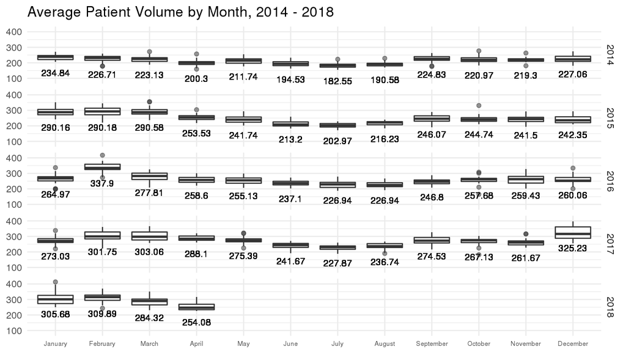

### Mean Comparison Analysis

```
Pairwise mean comparisons (t-test)
Data      : meanComparison
Variables : ADT_MONTH, avg
Samples   : independent
Confidence: 0.95
Adjustment: Bonferroni

 ADT_MONTH    mean  n     sd    se     ci
   January 273.406 35 28.004 4.734  9.620
  February 293.183 35 39.633 6.699 13.614
     March 276.039 35 30.846 5.214 10.596
     April 250.968 35 32.132 5.431 11.038
       May 245.873 28 27.500 5.197 10.663
      June 221.607 28 22.835 4.315  8.854
      July 209.995 28 21.022 3.973  8.152
    August 217.580 28 21.454 4.054  8.319
 September 248.671 28 23.284 4.400  9.029
   October 248.037 28 20.527 3.879  7.960
  November 245.384 28 21.477 4.059  8.328
  December 264.143 28 40.899 7.729 15.859

 Null hyp.              Alt. hyp.                         diff    p.value
 January = February     January not equal to February     -19.777 1
 January = March        January not equal to March         -2.633 1
 January = April        January not equal to April         22.438 0.179
 January = May          January not equal to May           27.532 0.016
 January = June         January not equal to June          51.799 < .001
 January = July         January not equal to July          63.411 < .001
 January = August       January not equal to August        55.825 < .001
 January = September    January not equal to September     24.734 0.02
 January = October      January not equal to October       25.368 0.007
 January = November     January not equal to November      28.022 0.002
 January = December     January not equal to December       9.263 1
 February = March       February not equal to March        17.144 1
 February = April       February not equal to April        42.215 < .001
 February = May         February not equal to May          47.310 < .001
 February = June        February not equal to June         71.576 < .001
 February = July        February not equal to July         83.188 < .001
 February = August      February not equal to August       75.602 < .001
 February = September   February not equal to September    44.511 < .001
```

[output cut: 35 more lines]

```
 July = October         July not equal to October         -38.043 < .001
 July = November        July not equal to November        -35.389 < .001
 July = December        July not equal to December        -54.148 < .001
 August = September     August not equal to September     -31.091 < .001
 August = October       August not equal to October       -30.457 < .001
 August = November      August not equal to November      -27.804 0.001
 August = December      August not equal to December      -46.563 < .001
 September = October    September not equal to October      0.634 1
 September = November   September not equal to November     3.287 1
 September = December   September not equal to December   -15.471 1
 October = November     October not equal to November       2.654 1
 October = December     October not equal to December     -16.105 1
 November = December    November not equal to December    -18.759 1

Signif. codes:  0 '***' 0.001 '**' 0.01 '*' 0.05 '.' 0.1 ' ' 1
```

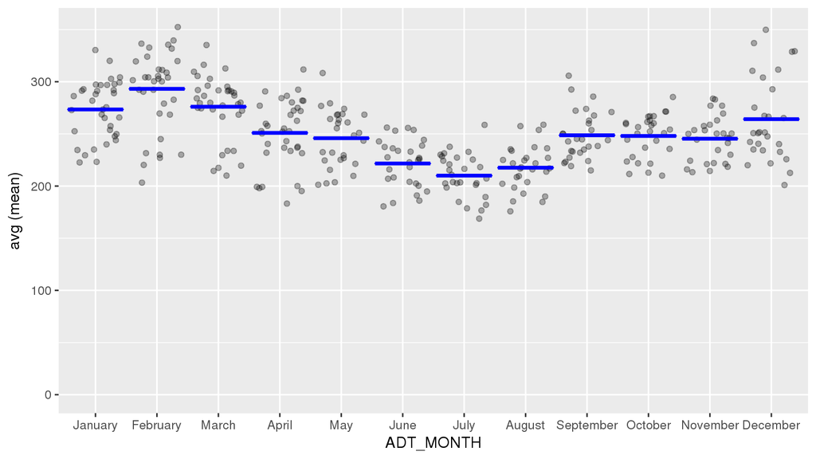

The differences of average patient volume across different months are greater. After Bonferroni adjustment (which reduce the likelihood of incorrectly reject the null hypothesis), we can roughly group them into three clusters:

- January, Feburary, March, and December
- April, May, September, October, and November
- June, July, August

## Linear Regression Model

To quantify the difference, we run a simple linear regression, using just `Year`, `Month` and `Weekdays` to explain the average patient volumes. Due to the fact that year 2018 only has the first 4 month data, so we exclude all observations recorded in year 2018.

```
Linear regression (OLS)
Data     : meanComparison
Filter   : ADT_YEAR != 2018
Response variable    : avg
Explanatory variables: ADT_YEAR, ADT_MONTH, ADT_WEEKDAYS
Null hyp.: the effect of x on avg is zero
Alt. hyp.: the effect of x on avg is not zero

                        coefficient std.error t.value p.value
 (Intercept)                243.931     3.937  61.966  < .001 ***
 ADT_YEAR|2015               34.626     2.430  14.251  < .001 ***
 ADT_YEAR|2016               45.840     2.430  18.867  < .001 ***
 ADT_YEAR|2017               59.886     2.430  24.648  < .001 ***
 ADT_MONTH|February          23.641     4.208   5.618  < .001 ***
 ADT_MONTH|March              8.427     4.208   2.002   0.046 *
 ADT_MONTH|April            -14.782     4.208  -3.513  < .001 ***
 ADT_MONTH|May              -19.491     4.208  -4.632  < .001 ***
 ADT_MONTH|June             -43.757     4.208 -10.398  < .001 ***
 ADT_MONTH|July             -55.370     4.208 -13.157  < .001 ***
 ADT_MONTH|August           -47.784     4.208 -11.355  < .001 ***
 ADT_MONTH|September        -16.693     4.208  -3.967  < .001 ***
 ADT_MONTH|October          -17.327     4.208  -4.117  < .001 ***
 ADT_MONTH|November         -19.980     4.208  -4.748  < .001 ***
 ADT_MONTH|December          -1.221     4.208  -0.290   0.772
 ADT_WEEKDAYS|Tuesday         1.497     3.214   0.466   0.642
 ADT_WEEKDAYS|Wednesday     -16.328     3.214  -5.080  < .001 ***
 ADT_WEEKDAYS|Thursday      -19.991     3.214  -6.220  < .001 ***
 ADT_WEEKDAYS|Friday        -21.028     3.214  -6.542  < .001 ***
 ADT_WEEKDAYS|Saturday      -22.150     3.214  -6.891  < .001 ***
 ADT_WEEKDAYS|Sunday        -17.581     3.214  -5.470  < .001 ***

Signif. codes:  0 '***' 0.001 '**' 0.01 '*' 0.05 '.' 0.1 ' ' 1

R-squared: 0.822,  Adjusted R-squared: 0.811
F-statistic: 72.928 df(20,315), p.value < .001
Nr obs: 336
```

The Base case is the average patient volume of all Mondays in January, 2014. We saw a year-on-year growth. We also observe that February is probably on average the busiest month, whereas July is the month that on average has the least amount of patients. One thing that is counter-intuitive is that Tuesday being the busiest day through the week averagely.

## Average Patient Volume By Acuities

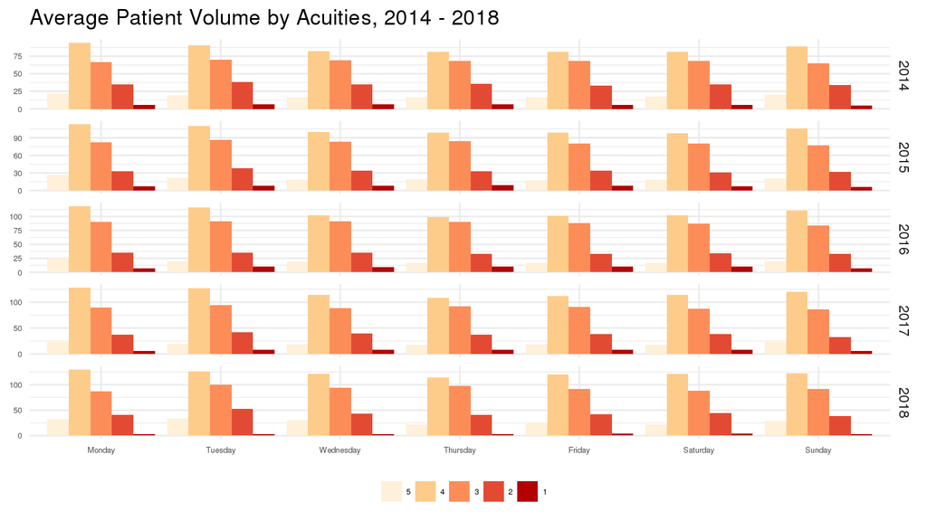

The graph showed that the distribution of different acuities shares the same pattern across the weekdays.